# Actividad 2.7 Regresión Logística

Raúl Correa Ocañas

2024-09-01

# Preparación de Datos

```r
train_index = which(Weekly$Year <= 2008)
test_index = which(Weekly$Year > 2008)

Weekly_train = Weekly[train_index,]
Weekly_test = Weekly[test_index,]
```

# Modelo de Regresión Logística

```r
log_model = glm(Direction ~ Lag2, Weekly_train, family='binomial')

summary(log_model)
```

```
##
## Call:
## glm(formula = Direction ~ Lag2, family = "binomial", data = Weekly_train)
##
## Coefficients:
##             Estimate Std. Error z value Pr(>|z|)
## (Intercept)  0.20326    0.06428   3.162  0.00157 **
## Lag2         0.05810    0.02870   2.024  0.04298 *
## ---
## Signif. codes:  0 '***' 0.001 '**' 0.01 '*' 0.05 '.' 0.1 ' ' 1
##
## (Dispersion parameter for binomial family taken to be 1)
##
##     Null deviance: 1354.7  on 984  degrees of freedom
## Residual deviance: 1350.5  on 983  degrees of freedom
## AIC: 1354.5
##
## Number of Fisher Scoring iterations: 4
```

```r
summary(Weekly_train$Lag2)
```

```
##     Min.  1st Qu.   Median     Mean  3rd Qu.     Max.
## -18.1950  -1.1470   0.2340   0.1278   1.3370  12.0260
```

```r
beta_1 = log_model$coefficients["Lag2"]
intercept = log_model$coefficients["(Intercept)"]
Lag2_value = 0.0061

odds_increase = exp(beta_1)
prob = 1/(1+exp(-(intercept + beta_1 * Lag2_value)))

cat("La probabilidad de que el mercado suba aumenta", odds_increase, "veces por cada unidad de Lag2\n")
```

```
## La probabilidad de que el mercado suba aumenta 1.059816 veces por cada unidad de Lag2
```

```r
cat("La probabilidad de que el mercado suba cuando Lag2 =", Lag2_value, "es de", prob, "\n")
```

```
## La probabilidad de que el mercado suba cuando Lag2 = 0.0061 es de 0.5507278
```

Observamos que el modelo indica coeficientes $0.2033$ para $\beta_0$ y $0.0581$ para $\beta_1$. Adicionalmente, sus respectivos valores $p$ son de $0.001$ y $0.042$, ambos siendo estadísticamente significativos. Por lo tanto, se puede inferir que los coeficientes son diferentes de $0$ y son significativos al modelo. En este contexto, el $\beta_1$ indica que por cada unidad de cambio de Lag2, cuanto cambió habrá en la función logit. Por lo tanto: Por por cada unidad que se incrementa la variable Lag2, se espera que el logaritmo de odds de la variable Direction se incremente en promedio $0.0581$ unidades. Es decir, por cada unidad que se incrementa la variable Lag2, los odds de que Direction sea “Up” se incrementan en promedio $e^{\beta_1}\approx1.05982$ veces. Sin tener el dato específico del ROI por quincena del S&P 500 el día de hoy, se toma el estimado de $1.22 \% / 2\approx0.61\%$ (siendo $1.22\%$ el ROI del mes de Julio 2024). Esto corresponde a una probabilidad de una dirección de Up de $55.1\%$.

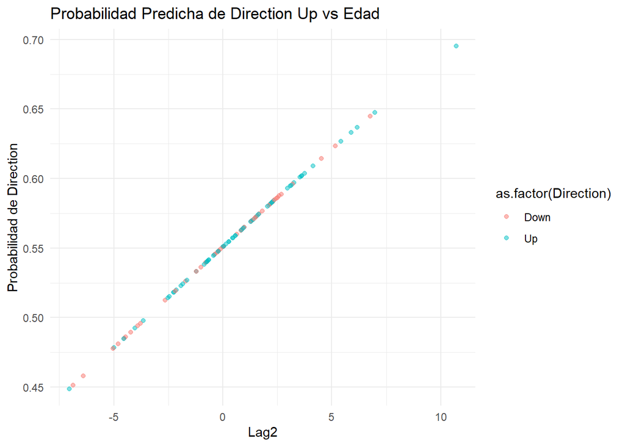

```r
Weekly_test$preds = predict(log_model, newdata = data.frame(Lag2 = Weekly_test$Lag2), type = "response")

ggplot(Weekly_test, aes(x = Lag2, y = preds)) +
  geom_point(aes(color = as.factor(Direction)), alpha = 0.5) +
  labs(title = "Probabilidad Predicha de Direction Up vs Edad",
       x = "Lag2",
       y = "Probabilidad de Direction") +
  theme_minimal()
```

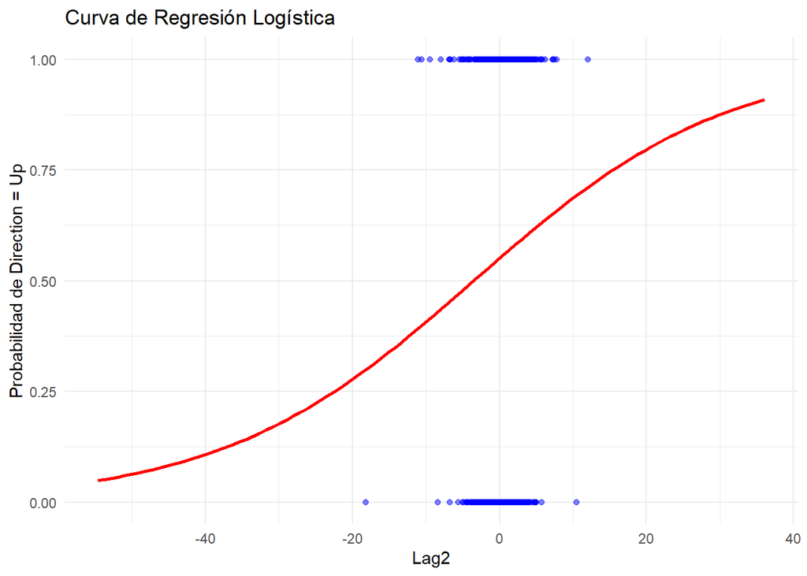

```r
Lag2_range <- seq(min(Weekly_train$Lag2)*3, max(Weekly_train$Lag2)*3, length.out = 100)

prob_preds <- predict(log_model, newdata = data.frame(Lag2 = Lag2_range), type = "response")

df_curve <- data.frame(Lag2 = Lag2_range, Probabilidad = prob_preds)

ggplot() +
  geom_point(data = Weekly_train, aes(x = Lag2, y = as.numeric(Direction) - 1), alpha = 0.5, color = "blue") +
  geom_line(data = df_curve, aes(x = Lag2, y = Probabilidad), color = "red", size = 1) +
  labs(title = "Curva de Regresión Logística",
       x = "Lag2",
       y = "Probabilidad de Direction = Up") +
  theme_minimal()
```

# Evaluación del Modelo

## ANOVA para Diferencia entre Modelo Nulo y Modelo Residual

```r
null_model = glm(Direction ~ 1, data = Weekly_train, family = "binomial")
anova_resultado = anova(null_model, log_model, test = "Chi")
print(anova_resultado)
```

```
## Analysis of Deviance Table
##
## Model 1: Direction ~ 1
## Model 2: Direction ~ Lag2
##   Resid. Df Resid. Dev Df Deviance Pr(>Chi)
## 1       984     1354.7
## 2       983     1350.5  1   4.1666  0.04123 *
## ---
## Signif. codes:  0 '***' 0.001 '**' 0.01 '*' 0.05 '.' 0.1 ' ' 1
```

Al haber obtenido un valor de $p$ de $0.041$, se infiere que el modelo con Lag2 como variable predictora es estadísticamente significativo contra un modelo sin predictores.

## Matriz de Contingencia

```r
Weekly_test$preds_class = ifelse(Weekly_test$preds > 0.5, 1, 0)

tabla_contingencia = table(Predicciones = Weekly_test$preds_class, Real = Weekly_test$Direction)
print(tabla_contingencia)
```

```
##             Real
## Predicciones Down Up
##            0    9  5
##            1   34 56
```

```r
tasa_error = 1 - sum(diag(tabla_contingencia)) / sum(tabla_contingencia)
sensibilidad = tabla_contingencia[2, 2] / sum(tabla_contingencia[2, ])
especificidad = tabla_contingencia[1, 1] / sum(tabla_contingencia[1, ])

cat("Tasa de Error:", tasa_error, "\n")
```

```
## Tasa de Error: 0.375
```

```r
cat("Sensibilidad:", sensibilidad, "\n")
```

```
## Sensibilidad: 0.6222222
```

```r
cat("Especificidad:", especificidad, "\n")
```

```
## Especificidad: 0.6428571
```

## Diagrama de Mosaico

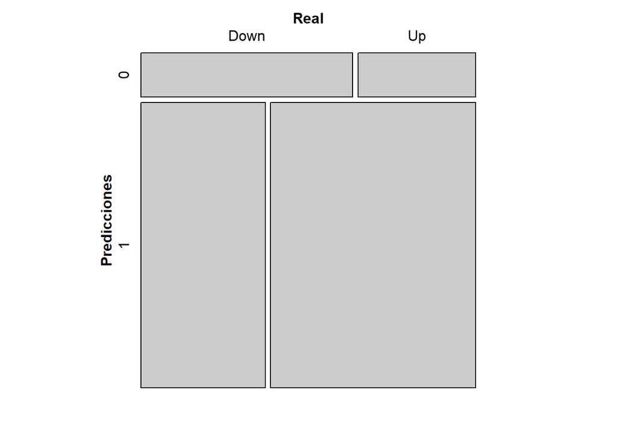

```r
mosaic(tabla_contingencia)
```

# Validación de Supuestos

## Linealidad

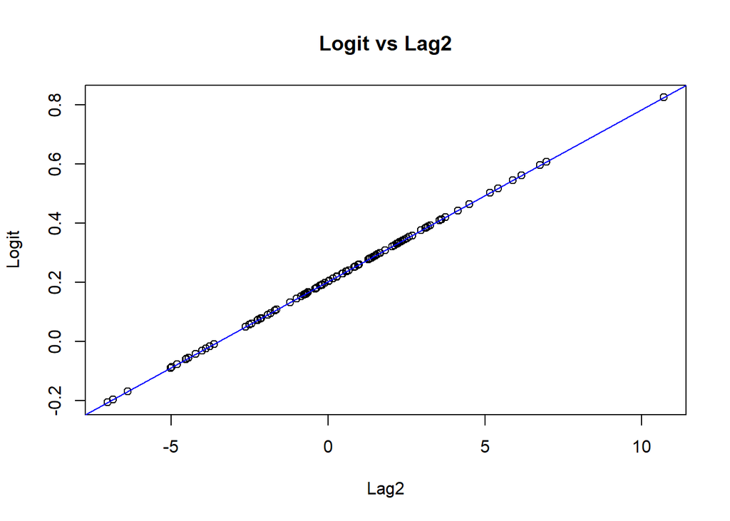

```r
logit_preds <- log(Weekly_test$preds / (1 - Weekly_test$preds))
plot(logit_preds ~ Weekly_test$Lag2, main = "Logit vs Lag2",
     xlab = "Lag2", ylab = "Logit")
abline(lm(logit_preds ~ Weekly_test$Lag2), col = "blue")
```

Se observa que el modelo se ajusta adecuadamente a los valores logit de la variable categórica representada numericamente, por lo cual se infiere que una relación lineal entre Lag2 y la función logit aplicada a Direction.

## Ausencia de Multicolinealidad

```r
vif_result = tryCatch({
  vif(log_model)
}, error = function(e) {
  # Captura del mensaje de error
  paste("Error:", e$message)
})

# Imprimir el resultado (si hubo un error, se mostrará el mensaje)
print(vif_result)
```

```
## [1] "Error: model contains fewer than 2 terms"
```

Este error ocurre debido a que no se puede tener multicolinealidad para un modelo de una sola variable predictora. Por lo tanto, se cumple el supuesto de multicolinealidad.

## Independencia de los Residuos.

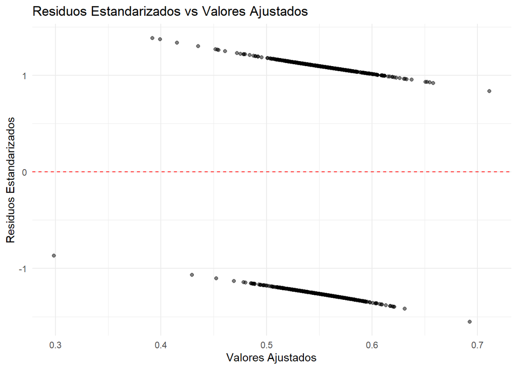

```r
residuals_standardized = rstandard(log_model)
fitted_values = fitted(log_model)

residuals_df = data.frame(Fitted = fitted_values, Residuals = residuals_standardized)

# Crear el gráfico
ggplot(residuals_df, aes(x = Fitted, y = Residuals)) +
  geom_point(alpha = 0.5) +
  geom_hline(yintercept = 0, color = "red", linetype = "dashed") +
  labs(title = "Residuos Estandarizados vs Valores Ajustados",
       x = "Valores Ajustados",
       y = "Residuos Estandarizados") +
  theme_minimal()
```

```r
dwtest(log_model)
```

```
##
##  Durbin-Watson test
##
## data:  log_model
## DW = 2.154, p-value = 0.9923
## alternative hypothesis: true autocorrelation is greater than 0
```

Tanto el gráfico como la prueba de Durbin-Watson afirman que no se tiene evidencia estadística para rechazar la hipótesis nula, por lo que los residuos son independientes.

## Tamaño de Muestra

```r
Weekly_train %>%
  group_by(Direction) %>%
  summarise(count = n())
```

```
## # A tibble: 2 × 2
##   Direction count
##   <fct>     <int>
## 1 Down        441
## 2 Up          544
```

Se tienen suficientes muestras para ambos casos para poder hacer un análisis de regresión logística.